# Solar Permitting in Virginia: waiting for approval

Lauren Woomer

2026-05-11

# Virginia’s energy problem

Demand for electricity has surged over the past decade, encouraged by growing electrification and the data center boom in Northern Virginia. This has been accompanied by a sharp rise in electricity prices.

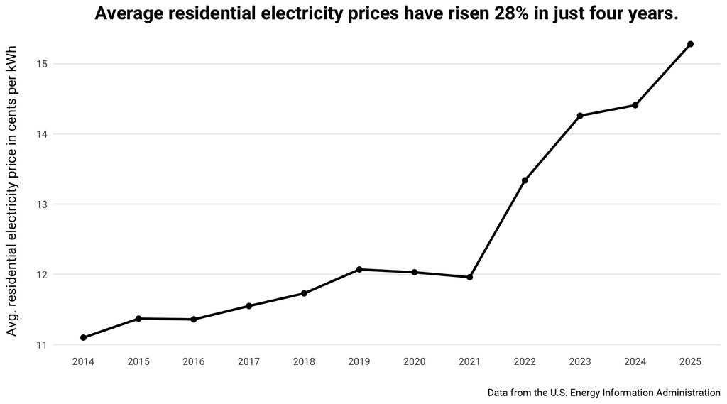

In order to help meet Virginia’s growing electricity needs in a way that is environmentally sustainable, Virginia’s legislature enacted the **Virginia Clean Economy Act (VCEA)** in 2020.

The VCEA mandated that Virginia’s public utility companies, Dominion Energy and Appalachian Power, deliver **electricity from 100% renewable sources by 2045 and 2050**, respectively. It also mandated that **16,100 megawatts (MW) of electricity from solar and onshore wind be generated by 2035**. Due to solar being cheaper and easier to build, this electricity will realistically need to come from solar projects.

In 2025, Virginia generated 9,083 MW from utility-scale solar and 50 MW from wind, according to data from the U.S. Energy Information Administration. This means that while we’re making progress towards these targets, **we still need a lot more solar energy brought online in the next eight years**.

# The state of solar permitting

In Virginia, **all solar projects that generate 500 or more kilowatts (KW) or occupy two or more acres must be approved by the local government** in addition to the relevant state permitting bodies.

**Initially the response from local governments was warm.** Solar projects start ramping up Virginia around 2015, presumably helped along by the VirginiaSAVES Green Community Program that offers low cost financing to private companies, non-profits and local governments to fund renewable energy projects.

**The response from local governments started to cool down around 2022**, though, corresponding with the start of the renewable-skeptical Gov. Youngkin’s term. This is also the year that the Inflation Reduction Act passed on the national stage, which among other things established subsidies for renewable energy projects. The complete lack of Republican support for the IRA reflected the bitter partisan divide on renewable energy and climate change.

All data in the charts that follow comes from the [Virginia Solar Dashboard](https://solardatabase.coopercenter.org/solar/) published by the University of Virginia’s Weldon Cooper Center for Public Service. This database tracks all known solar projects in the state of Virginia at all stages in the permitting process.

## Total Solar Permits

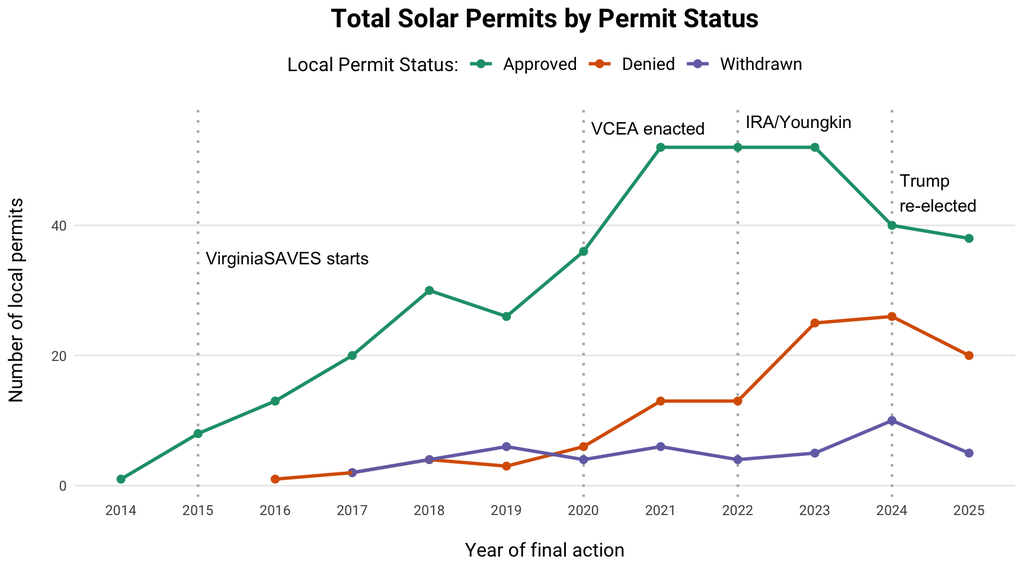

## Percent of Total Permits

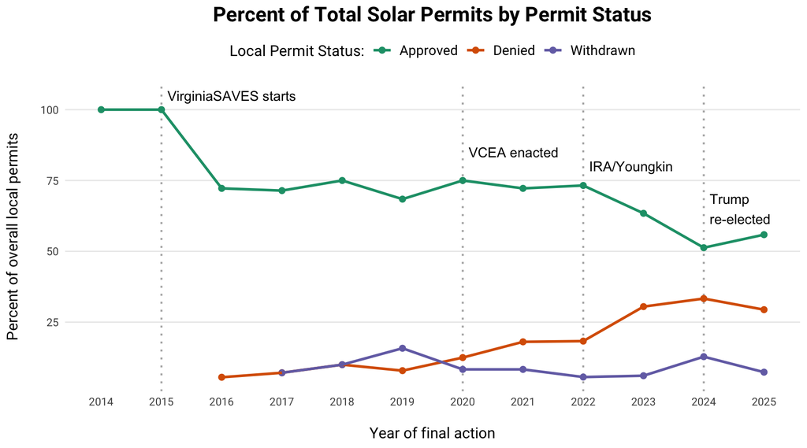

# Who bears the load?

Solar projects are not distributed evenly throughout Virginia, however. The **Southern region** of the state has seen the most solar projects, likely due to its abundance of flat, open land and lower population density. This is followed distantly by the **Central and Hampton Roads regions**.

Not only are approvals concentrated in these regions…

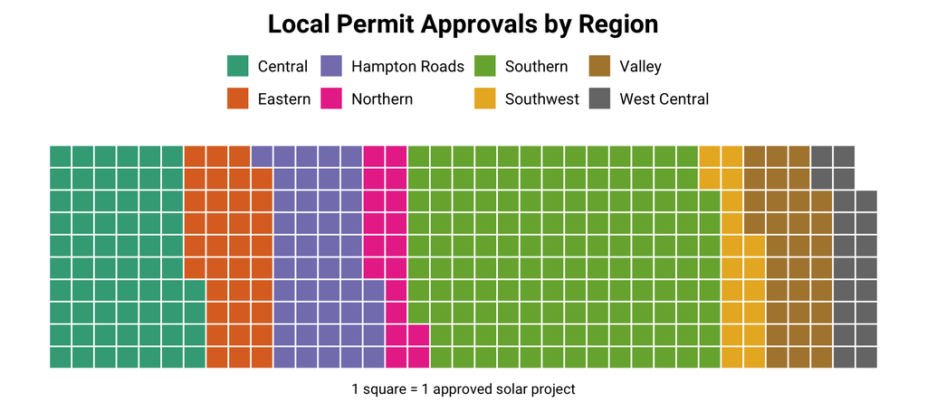

but the Southern region far outstrips other regions in both the number of megawatts approved to be generated and the number of acres designated for approved solar projects, with the next highest region having less than a third of the number.

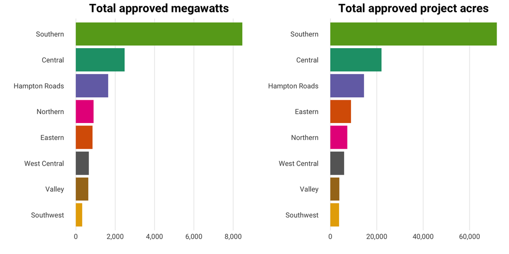

This translates into more project denials in the Southern and Central regions.

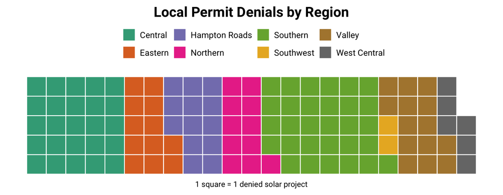

Permit denials are only part of the story, however. **[64% of Virginia’s counties/independent cities](https://marec.us/va-siting-reform/) have either banned utility-scale solar projects or passed restrictive ordinances that make it more difficult and expensive to develop solar projects.** Restrictions include acreage caps, limitations on what kind of land solar installations can be built on, and requirements for installations to be set back a certain distance from features like roads or other properties. These ordinances can lead to project withdrawals or incentivize solar developers to look elsewhere to build their projects.

# Reasons for resistance

It’s important to understand the reasons for this resistance if it is to be overcome. Some main reasons are:

- **Concerns about preserving local character:** In southern Virginia counties, residents are often concerned about [solar installations replacing farmland and forested land](https://virginiamercury.com/2024/10/30/solar-developers-seeking-changes-to-local-siting-process-again/). These concerns can be aesthetic ones about their area developing a more industrial feel. However, they can also be practical ones about losing the farming that has long defined their communities. For example, some rural residents are open to solar installations being placed in already industrial or undesirable land, but don’t want to see land that is good for farming replaced.
- **Environmental and health concerns:** Another common concern is about the environmental impacts of solar installations. These include the [clearing of trees and issues with stormwater runoff](https://www.whro.org/environment/2025-08-14/somethings-gotta-give-virginia-is-struggling-to-balance-energy-needs-with-local-tensions-over-solar-development) exacerabating soil erosion, which occurred in some poorly designed installations in Virginia. [Misinformation campaigns](https://www.npr.org/2023/02/18/1154867064/solar-power-misinformation-activists-rural-america) by groups like Citizens for Responsible Solar build on these reasonable fears with false claims about the bad environmental and health effects of solar farms, such as that they ruin the land that they’re on, poison groundwater with toxic chemicals, and cause cancer.
- **Equity concerns:** Finally, some in southern Virginia counties express [frustration with being asked to take on more than their fair share](https://cardinalnews.org/2024/01/30/southside-never-asked-to-be-a-magnet-for-solar-farms/) of the solar infrastructure that the state as a whole needs. While most power is consumed by metropolitan areas, rural areas bear the brunt of generating that power. They are the ones who have to see a solar installation go up in their community, when people in all types of communities tend to balk at anything unsightly being developed in their backyard. Some residents of rural Virginia resent this unbalance and would like to see solar distributed more fairly across the state.

# Where does this leave us?

This rise in local permit denials results in a whole lot of megawatts being left on the table. **From 2023-2025, 2,814 MW of potential solar generation was denied by local governments.** This is 18% of the solar energy needed to meet the VCEA’s 2035 solar generation goal, and [enough energy to power 325,186 homes](https://seia.org/whats-in-a-megawatt/).

One hopeful note is that in 2025, the amount of generation approved started to outpace the amount of generation denied or withdrawn again. If we can continue this momentum into the future, there is hope for solar generation to recover, especially with a more renewable-friendly governor in place.

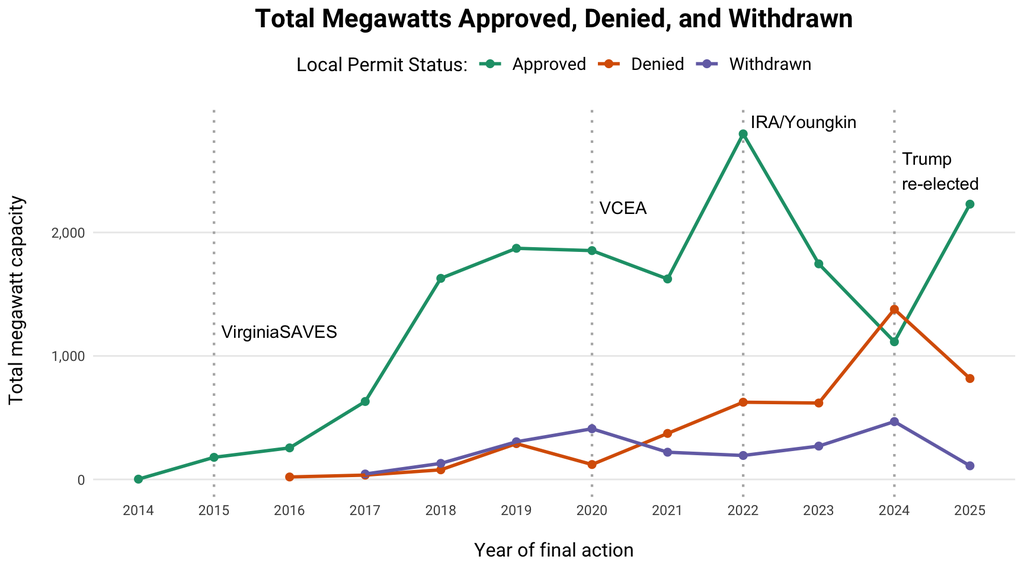

Just this spring, Virginia’s legislature passed a **[new solar siting reform law](https://lis.virginia.gov/bill-details/20261/HB711)**. This law **bans solar bans**, requiring local governments to assess each solar project on its merits and, if they reject it, to file their reasons for doing so with state regulators. It also **establishes new siting guidelines designed to put more safeguards in place for communities**, including recommended setbacks from other properties, minimized visual impacts, and environmental protections. Local governments are still free to reject proposals and to negotiate the actual specifications of the projects in their county, even if they don’t align with the siting guidelines.

While this new law clears the way for more solar projects to be approved in Virginia in principle, there is a risk that it may backfire in practice. This is because it still preserves the very dynamic that many in rural Virginia are critical of–that of urban Democrats telling them what they need to do with their land. The law passed along party lines, over the objections of many county governments and Virginia’s Farm Bureau.

While the siting reforms included in the law attempt to speak to some of the environmental and aesthetic concerns mentioned above, **more work needs to be done to address the concerns of rural communities and incentivize them to allow solar development on their land**. This could include the use of [Community Benefit Agreements](https://www.energy.gov/sites/default/files/2024-12/CBA%20Guidance%20FAQ.pdf), where developers agree to provide certain benefits to a host community, such as infrastructure, services, or energy bill reduction. It could also include [more outreach and collaboration efforts from developers](https://virginiabusiness.com/virginia-solar-local-opposition-challenges/) so that the development doesn’t feel like it’s coming from outside without concern for or input from local communities.